# Proteome-transcriptome-overlaps

August 05, 2022

# Loading tables

Loading tables with patient peptide protein matches, and trasncriptomics table with BCR sequences from all patients.

The peptide-protein match table, with annotated CDR - FWR region was generated by running the `peptide_matches_CDR3.R` script on the raw proteomics data as well as the IgBlast transcriptomics data, providing the amino acid sequences of the BCRs and their regions.

# Match distribution before filtering

Number of proteome peptide matchings per time point to the transcriptome before multimatch filtering:

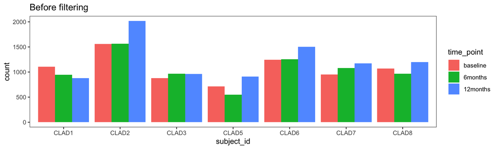

Same plot as boxplot with counts per patient:

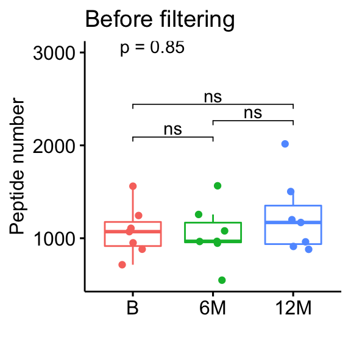

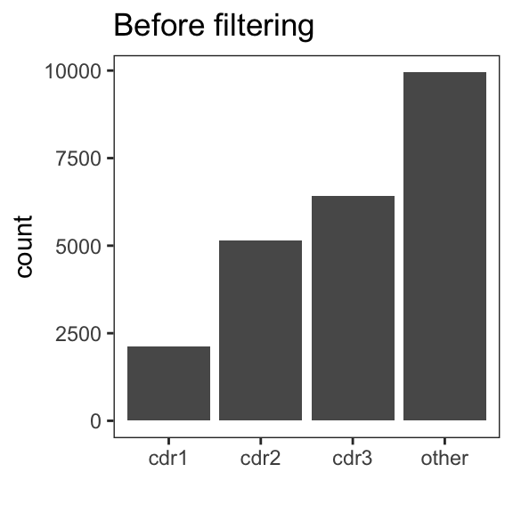

# Multimatch filtering

Filtering peptides that have a multimatch (matching to more than one BCR transcriptome sequence). If those peptides are matching more than one BCR sequence, if those sequences are from different BCR clones, then these are eliminated.

Number of peptide matches per patient and time point after filtering:

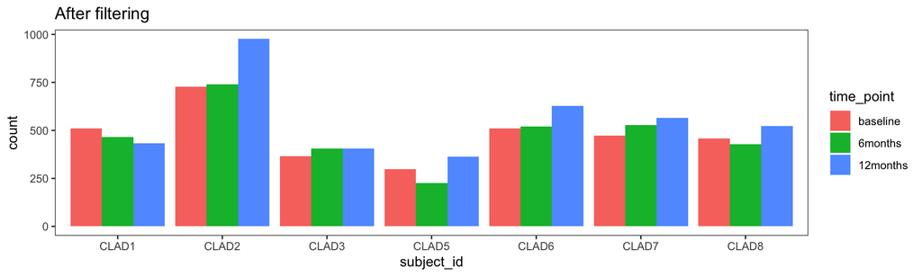

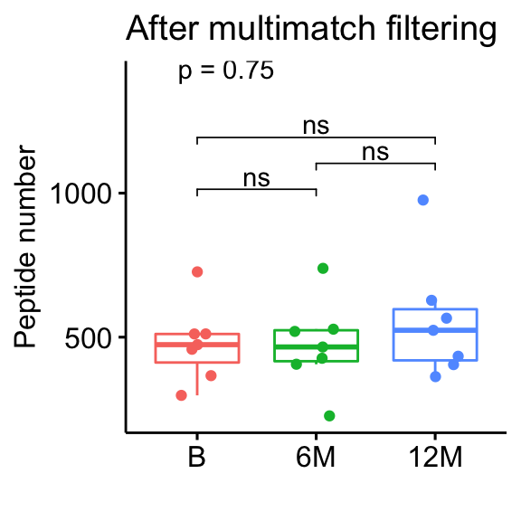

Number of protein matches per peptide after filtering:

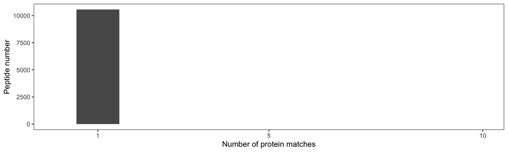

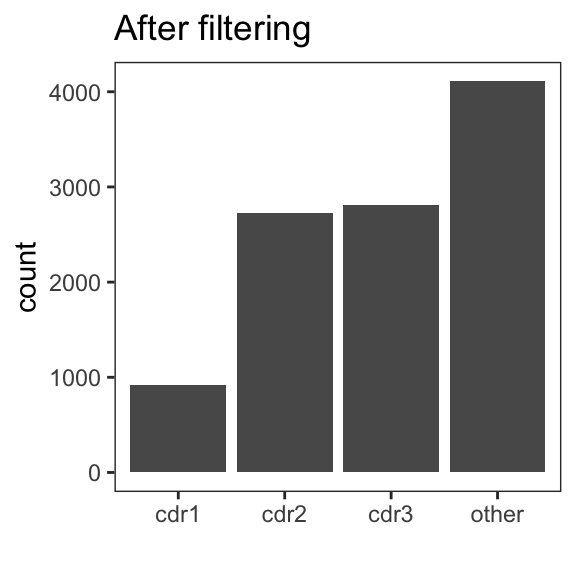

Number of amino acids overlaping in each of the cdr regions:

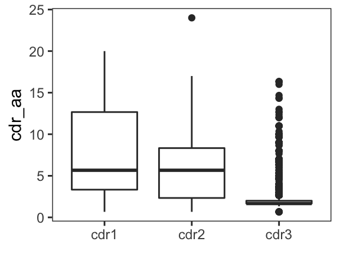

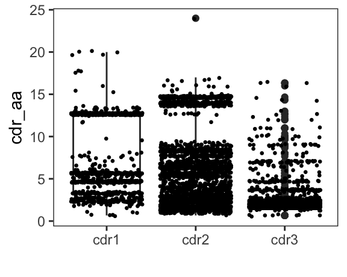

Number of peptide matches by B-cell clone

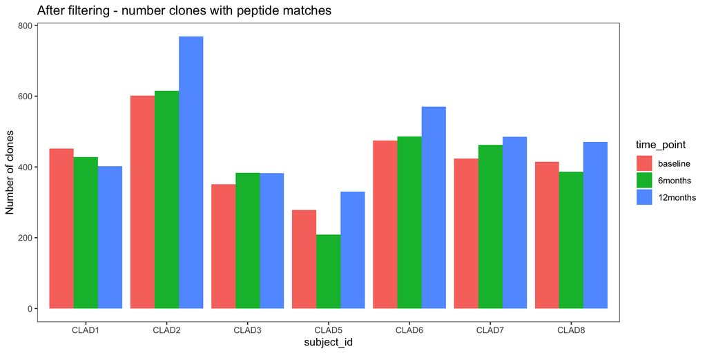

# Further filtering of peptides that have 3 aa in a cdr region

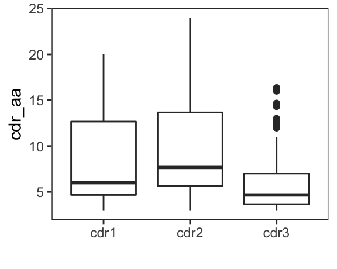

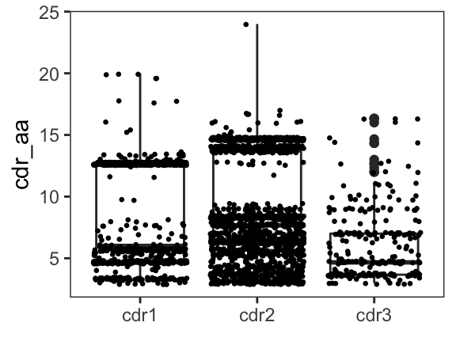

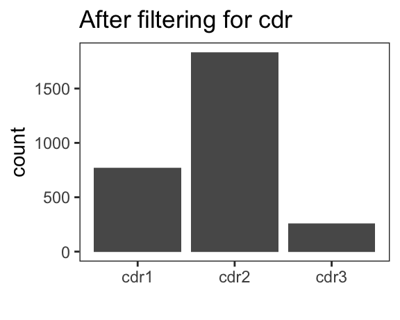

Number of peptide matches after filtering per patient and time point, cdr only:

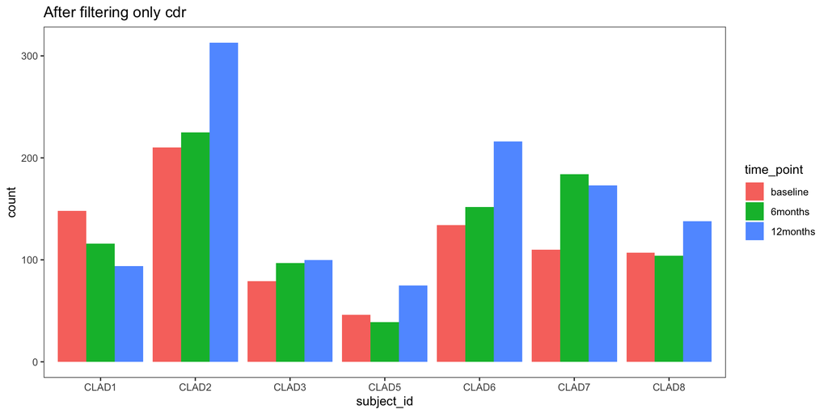

Number of peptide matches after multimatch filtering, cdr only:

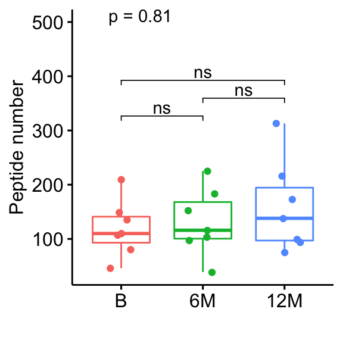

Integrating transcriptomics time point information:

Number of sequence matches in proteome, colored by which time point those sequences were matching on the transcriptome

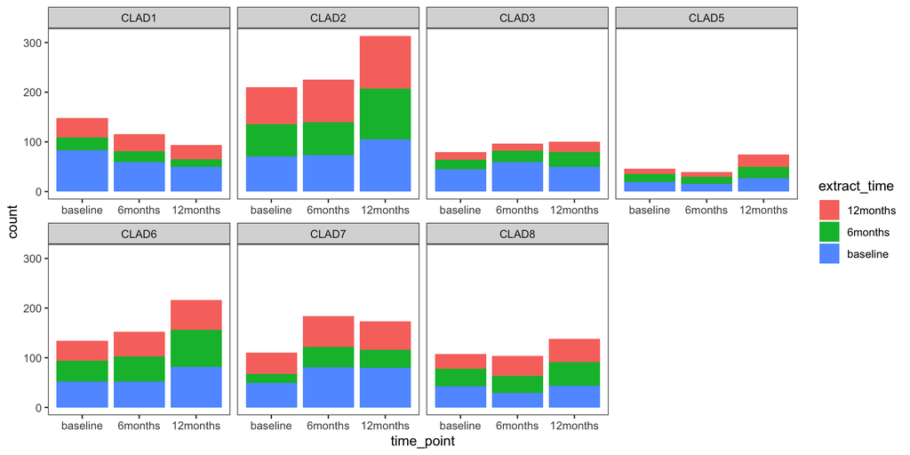

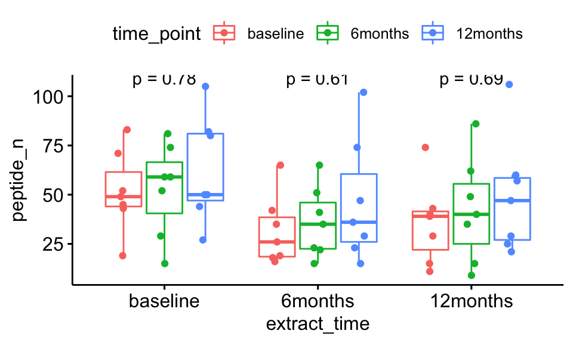

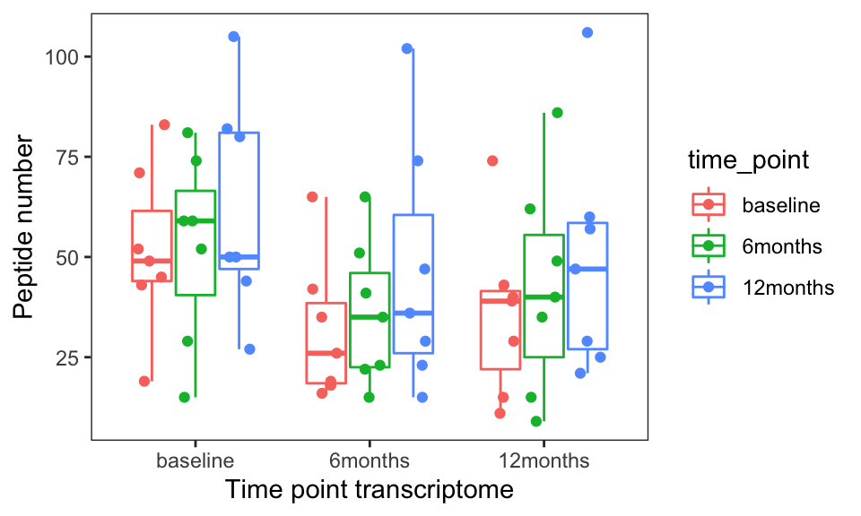

Number of sequence matches in proteome, colored by Ig isotype of the BCR sequence in transcriptome

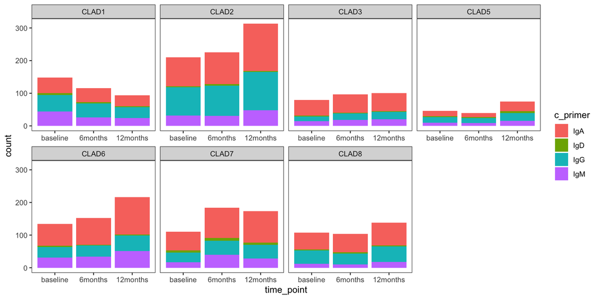

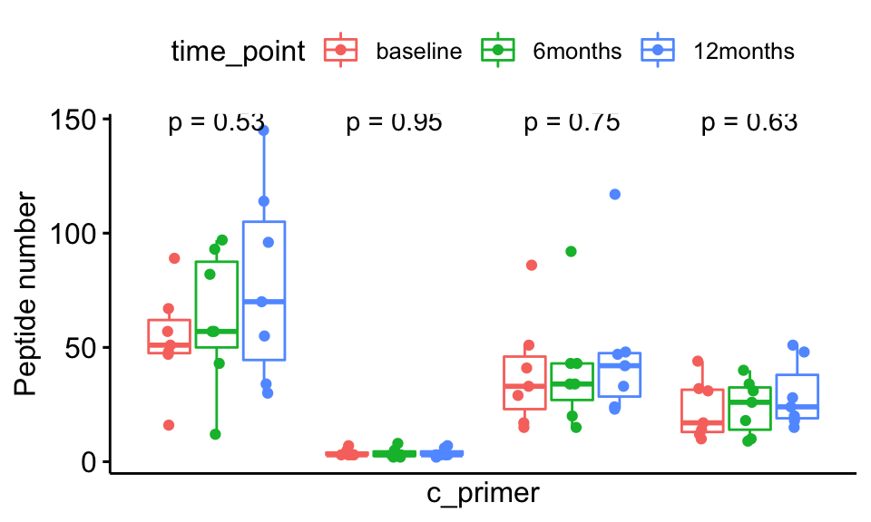

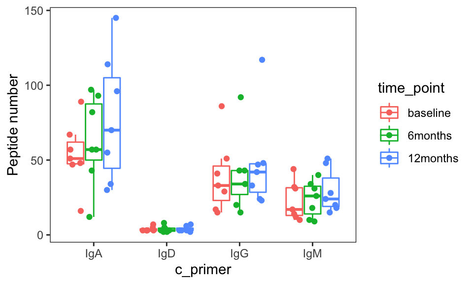

Number of sequence matches in proteome, colored by population of origin of the BCR sequence in transcriptome

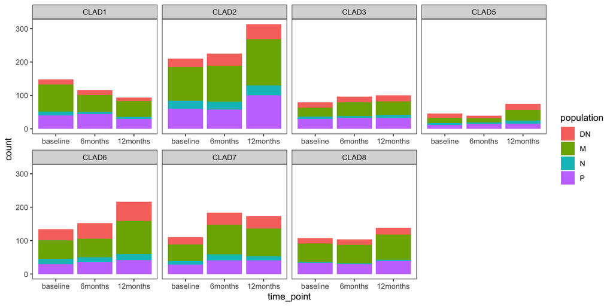

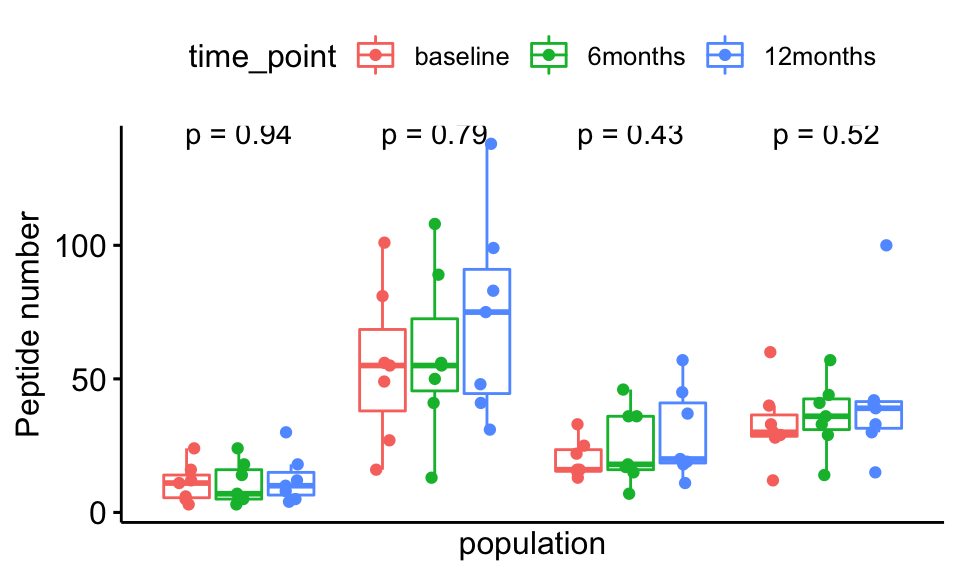

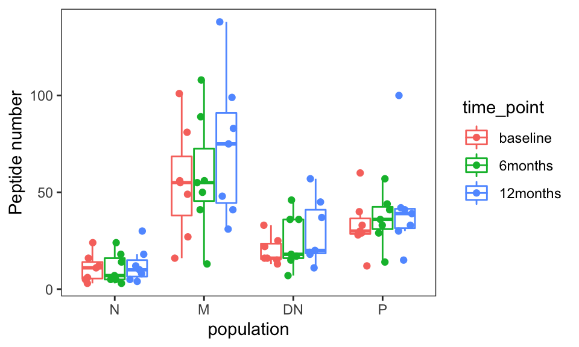

## Analysis of number of clones

Number of clone matches after filtering per patient and time point, cdr only

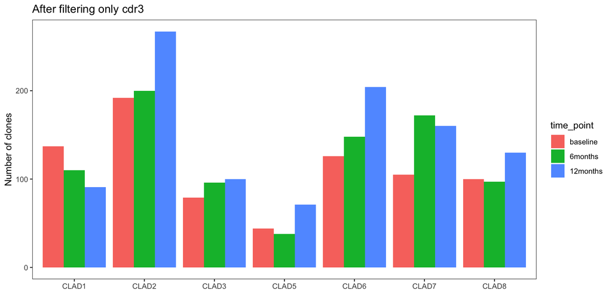

Figure with all boxplots:

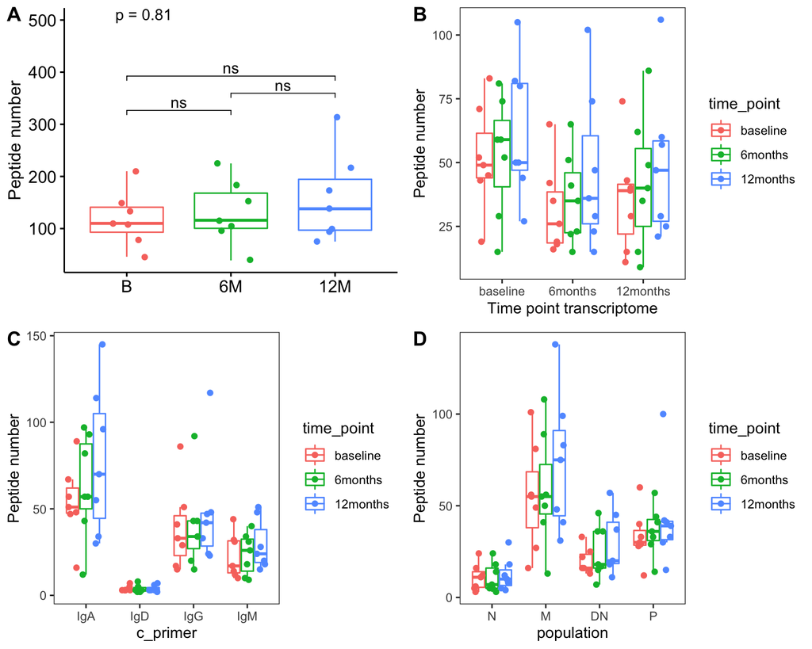